# YJNRC18

This is a report on TRD analyses of cross YJNRC18.

```r
# get the data

library(tidytable)
library(ggplot2)
library(naturalsort)
library(scales)
library(stringr)

AF_across_genome<-fread(paste0("~/data/TRD/results/shiny/", cross, "-AF.csv.gz"))

TRD_regions<-fread(paste0("~/data/TRD/results/shiny/", cross, "-TRD_regions.csv.gz"))
```

# 1 The two parents

```r
# load the Excel crosses file

crosses_xlsx=readxl::read_xlsx("~/data/trd/Crosses.xlsx", sheet=2)
cc=data.frame("Cross ID"=c(paste0("ChrisC",1:8)),
                                  "Short name 1"=c("ACP","BAP","CCD","ATE","ACK","AKE","BAH","ANG"),
                                  "Short name 2"=c("BFP","CMP","CPG","SACE_YCR","ACV","BAH","CGD","CEI"), stringsAsFactors=FALSE)
colnames(cc)=str_replace_all(colnames(cc), fixed("."), " ")
crosses_all <- bind_rows(crosses_xlsx[,c("Cross ID","Short name 1","Short name 2")],
                        cc)

crosses_all_slice<-filter(crosses_all, `Cross ID` == cross)
strain_1<-pull(crosses_all_slice, `Short name 1`)
strain_2<-pull(crosses_all_slice, `Short name 2`)

count_segregants<-NA

if(cross %in% pull(crosses_xlsx, `Cross ID`)){
    count_segregants<-filter(crosses_xlsx, `Cross ID` == cross)%>%
                    pull(`Colonies in pool`)
}

# load the Victor clusters

df_Strains<-fread("~/TRD/Shiny/data/Victor/operationalTable_Full2543Sace_Clades.csv")

cluster_1<-filter(df_Strains, StandardizedName == strain_1)%>%pull(Clade)
cluster_2<-filter(df_Strains, StandardizedName == strain_2)%>%pull(Clade)

# load the ASD

ASD_comparisons<-fread("~/data/TRD/comparisons.csv")
ASD_value<-filter(ASD_comparisons, (row==strain_1 & col == strain_2) |
                                    (row==strain_2 & col==strain_1))%>%
                                    pull(dist)
ASD_value<-unique(ASD_value)

ASD_translated_value<-ASD_value*(1554384/12000000)
ASD_translated_value<-round(ASD_translated_value*100,2)
```

Cross YJNRC18 was done between ACI (NA) and AKI (NA). I managed to pool 1256.

The parental strains had an allele sharing distance of 0.040594, which I think should translate into 0.53% distance between the genomes.

# 2 TRD across genome

```r
# code below from TRD/02_TRD/01_getTRDs-GATK.R

chrs <- summarise(group_by(AF_across_genome, chr), maxpos = max(pos))
chrs <- chrs[naturalorder(chrs$chr), ]
chrs$global_pos <- cumsum(chrs$maxpos)

p<-ggplot(AF_across_genome, aes(global_pos, AD_A1 / sumCount)) +
  geom_point(alpha = 0.1, color = "grey") +
  geom_line(mapping = aes(global_pos, smoothed, color = abs(0.5 - smoothed)), inherit.aes = FALSE, linewidth = 2) +
  scale_color_viridis_c(option = "A", limits = c(0, 0.5)) +
  ylim(c(0, 1)) +
  geom_hline(yintercept = 0.5) +
  geom_vline(xintercept = chrs$global_pos) +
  geom_vline(xintercept=c(pull(TRD_regions,global_start),pull(TRD_regions,global_end)), color="red", linetype=2, alpha=0.5)+
  theme_bw(16) +
  ylab("Allele Frequency") +
  xlab("POS") +
  theme(legend.position = "none") +
  # geom_hline(yintercept = c(0.4,0.6))+
  ggtitle(cross) +
  labs(alpha = "Coverage") +
  scale_x_continuous(labels = comma)

TRD_regions<-mutate(TRD_regions,
                    length90=NA,
                    length80=NA,
                    length70=NA,
                    length60=NA,
                    maxStrength=NA)

for(i in 1:nrow(TRD_regions)){
    TRD_regions_slice<-slice(TRD_regions, i)
    AF_across_genome_here<-filter(AF_across_genome, chr==pull(TRD_regions_slice, chr_start) & global_pos >= pull(TRD_regions_slice, global_start) & global_pos <= pull(TRD_regions_slice, global_end))

    TRD_regions<-mutate(TRD_regions,
                        length90=ifelse(ID==pull(TRD_regions_slice,ID),sum((pull(AF_across_genome_here,AD_A1)/pull(AF_across_genome_here,sumCount))>=0.9 |
                        (pull(AF_across_genome_here,AD_A1)/pull(AF_across_genome_here,sumCount))<= 0.1),length90),
                        length80=ifelse(ID==pull(TRD_regions_slice,ID),sum((pull(AF_across_genome_here,AD_A1)/pull(AF_across_genome_here,sumCount))>=0.8 |
                        (pull(AF_across_genome_here,AD_A1)/pull(AF_across_genome_here,sumCount))<= 0.2),length80),
                        length70=ifelse(ID==pull(TRD_regions_slice,ID),sum((pull(AF_across_genome_here,AD_A1)/pull(AF_across_genome_here,sumCount))>=0.7 |
                        (pull(AF_across_genome_here,AD_A1)/pull(AF_across_genome_here,sumCount))<= 0.3),length70),
                        length60=ifelse(ID==pull(TRD_regions_slice,ID),sum((pull(AF_across_genome_here,AD_A1)/pull(AF_across_genome_here,sumCount))>=0.6 |
                        (pull(AF_across_genome_here,AD_A1)/pull(AF_across_genome_here,sumCount))<= 0.4),length60),
              maxStrength=ifelse(ID==pull(TRD_regions_slice,ID),ifelse(max(pull(AF_across_genome_here,AD_A1)/pull(AF_across_genome_here,sumCount))>max(pull(AF_across_genome_here,AD_A2)/pull(AF_across_genome_here,sumCount)),
                        max((pull(AF_across_genome_here,AD_A1)/pull(AF_across_genome_here,sumCount))),max((pull(AF_across_genome_here,AD_A2)/pull(AF_across_genome_here,sumCount)))),maxStrength))
}
```

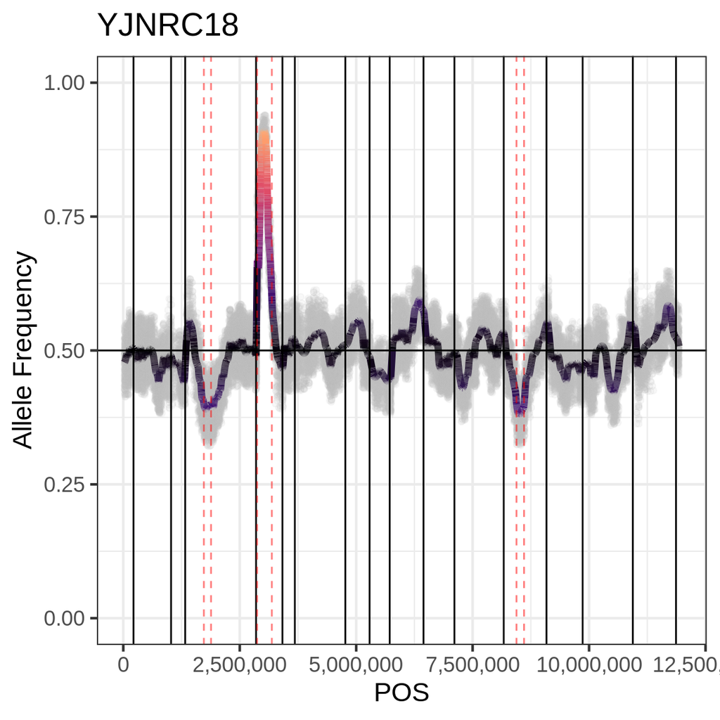

```r
p
```

## 2.1 List of TRD regions

The order is the same as highlighted in the plot above. IDs don’t necessarily increase continuously.

```r
library(reactable)

reactable(select(TRD_regions, ID, lengthSNPs, length90,
                    length80,
                    length70,
                    length60, lengthBp,
                    maxStrength, chr_start, chr_end, global_start, global_end))
```

| ID | lengthSNPs | length90 | length80 | length70 | length60 | lengthBp | maxStrength | chr_start | chr_end | global_start | global_end |
| --- | --- | --- | --- | --- | --- | --- | --- | --- | --- | --- | --- |
| 1 | 555 | 0 | 0 | 0 | 312 | 153857 | 0.679012345679012 | chromosome4 | chromosome4 | 1729624 | 1883481 |
| 3 | 1084 | 122 | 354 | 685 | 1052 | 316302 | 0.939622641509434 | chromosome5 | chromosome5 | 2872884 | 3189186 |
| 4 | 477 | 0 | 0 | 0 | 312 | 161807 | 0.677083333333333 | chromosome13 | chromosome13 | 8441735 | 8603542 |

# 3 Structural variants

```r
sv_plots_files<-paste0("~/data/trd/SV_analysis/",cross,".",c("sv_victor",
"syri_1","syri_2","mash1","mash2"),".RDS")

get_plots_if_they_exist<-function(x){
    if(file.exists(x)){
        return(readRDS(x))
    }else{
        return(NA)
    }
}

sv_plots<-lapply(sv_plots_files, get_plots_if_they_exist)
names(sv_plots)<-c("sv_victor",
"syri_1","syri_2","mash1","mash2")
```

## 3.1 Victor’s called SVs between parental strains

It is worth noting here that the sizes of SVs can be quite different between the parental strains and what has been merged on a population-level and is then shown here. Later, I will show quickly called SVs just between the two respective assemblies that one can then compare visually.

“TRD” regions added as well.

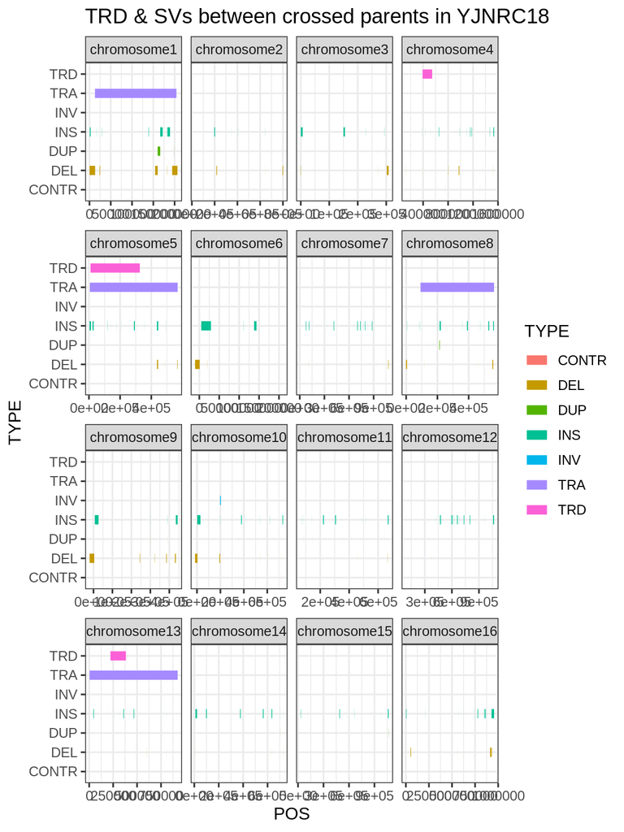

```r
sv_plots[["sv_victor"]]+theme_bw(12)
```

## 3.2 Re-called SVs using `syri`

I called SVs then between the two respective assemblies. Here I will show two plots, one from the “perspective” of parent 1 and one from parent 2 (i.e. with their coordinates on their chromosomes). Note: The chromosomes were ordered naturally, but since some are concatenated (due to translocations likely), ordering could be less-than-perfect.

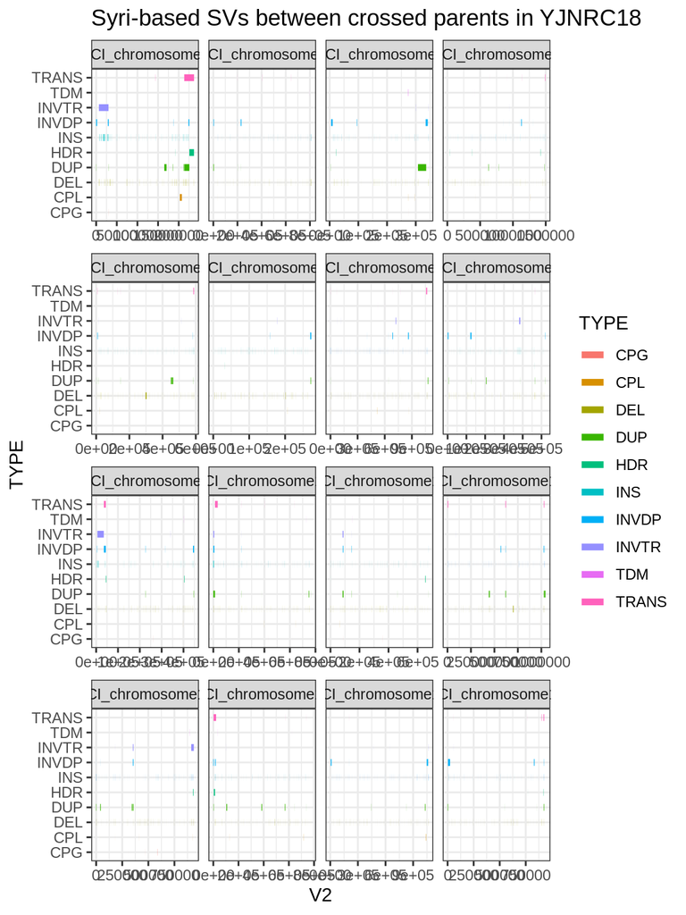

```r
sv_plots[["syri_1"]]+theme_bw(12)+ylab("TYPE")+labs(color="TYPE")
```

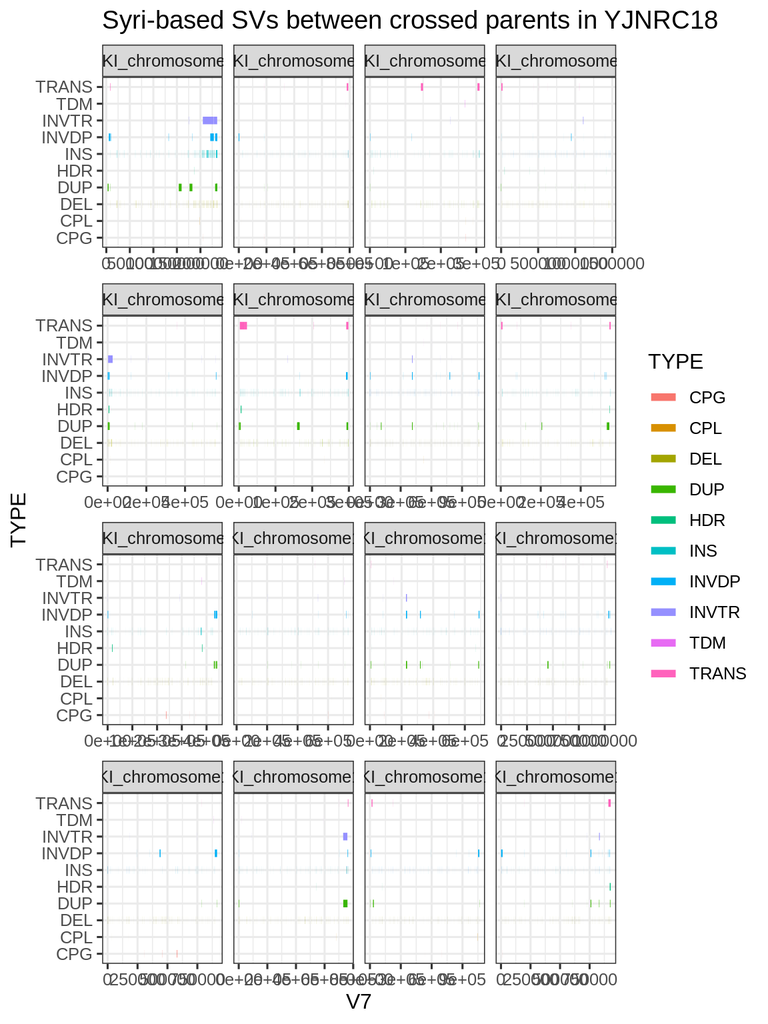

```r
sv_plots[["syri_2"]]+theme_bw(12)+ylab("TYPE")+labs(color="TYPE")
```

## 3.3 Dotplots

To help us understand some SVs better, I also produced dotplots, from both parents perspectives.

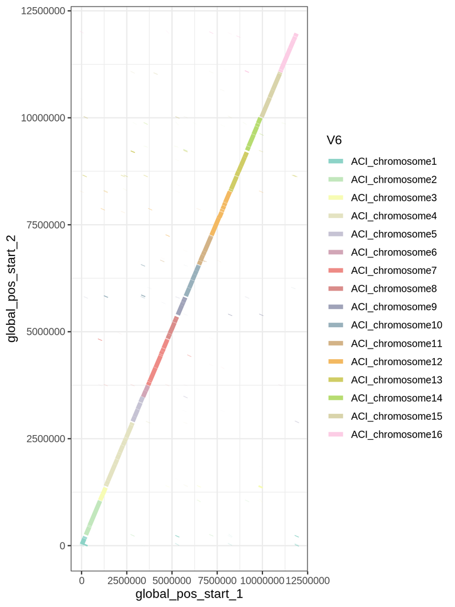

```r
sv_plots[["mash1"]]+theme_bw(12)
```

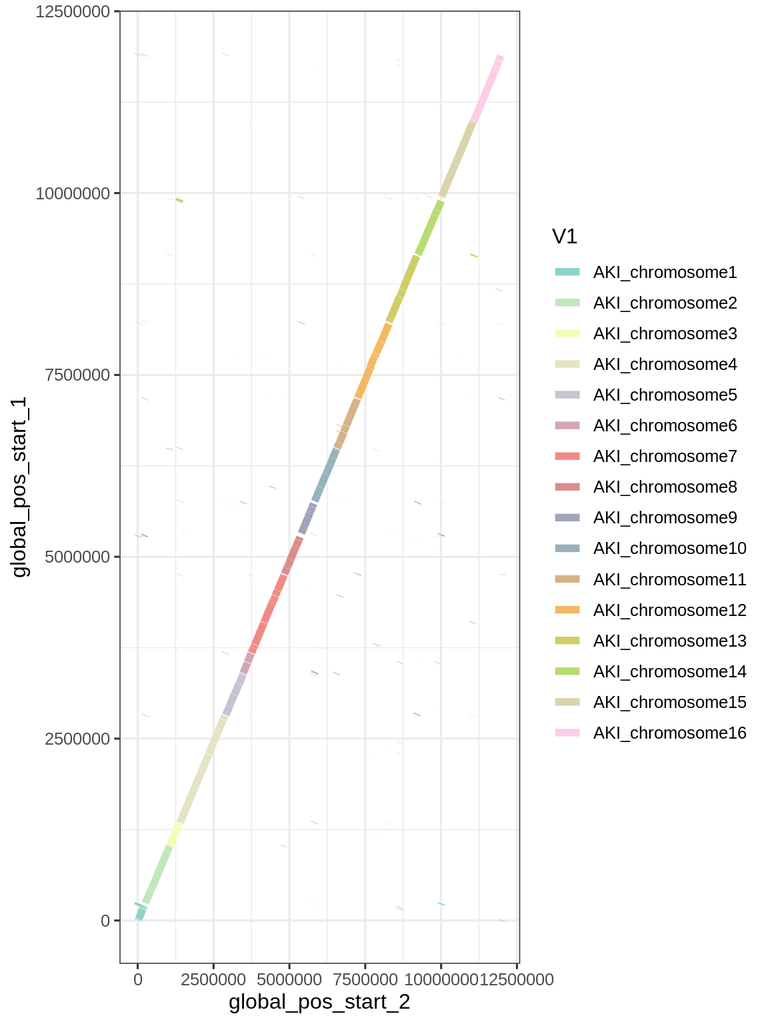

```r
sv_plots[["mash2"]]+theme_bw(12)
```

- Summary per TRD of % overlaps

```r
SV_data<-readRDS(paste0("/home/jnrunge/data/trd/SV_analysis/",cross,
                    ".SV_data.RDS"))


reactable(SV_data%>%filter(!is.na(TYPE))%>%
group_by(cross,ID,TYPE,source)%>%summarize(sum_LEN_rel=sum(LEN_rel),
sum_LEN=sum(LEN))%>%arrange(-sum_LEN))
```

| cross | ID | TYPE | source | sum_LEN_rel | sum_LEN |
| --- | --- | --- | --- | --- | --- |
| YJNRC18 | 3 | TRA | VictorSV | 1 | 316302 |
| YJNRC18 | 4 | TRA | VictorSV | 1 | 161807 |
| YJNRC18 | 3 | INS | VictorSV | 0.0594337057622146 | 18799 |
| YJNRC18 | 3 | INVTR | Syri | 0.0531201193795803 | 16802 |
| YJNRC18 | 4 | DUP | Syri | 0.0752686842967239 | 12179 |
| YJNRC18 | 4 | INS | VictorSV | 0.0428844240360429 | 6939 |
| YJNRC18 | 4 | INVDP | Syri | 0.0407460740264636 | 6593 |
| YJNRC18 | 3 | DEL | Syri | 0.0195604201048365 | 6187 |
| YJNRC18 | 4 | INVTR | Syri | 0.0366362394704803 | 5928 |
| YJNRC18 | 3 | DUP | Syri | 0.00682259359725832 | 2158 |

[output cut: 18 more lines]

# 4 Local phylogeny

- Summary

```r
LP_data<-fread("/home/jnrunge/data/trd/local_phylogenies_trd_analysis/TRD_regions_with_LP_data.csv.gz")

cross_val<-cross

LP_data<-filter(LP_data,cross==cross_val)%>%select(ID,PCA_eucldist_quantile_1,PCA_eucldist_sd_multiplier_1,IBS_eucldist_quantile_1,IBS_eucldist_sd_multiplier_1,tree_changes_quantile,tree_changes_sd_multiplier,PCA_eucldist_quantile_2,PCA_eucldist_sd_multiplier_2,IBS_eucldist_quantile_2,IBS_eucldist_sd_multiplier_2)

LP_data<-pivot_longer(LP_data, -ID)

LP_data<-mutate(LP_data, value=round(value,2), abs=round(abs(value),2))

reactable(LP_data%>%arrange(-abs))
```

| ID | name | value | abs |
| --- | --- | --- | --- |
| 1 | IBS_eucldist_sd_multiplier_2 | 1.72 | 1.72 |
| 3 | tree_changes_sd_multiplier | -1.49 | 1.49 |
| 4 | tree_changes_sd_multiplier | -1.02 | 1.02 |
| 1 | IBS_eucldist_quantile_2 | 0.95 | 0.95 |
| 1 | IBS_eucldist_quantile_1 | 0.71 | 0.71 |
| 1 | PCA_eucldist_quantile_1 | 0.61 | 0.61 |
| 4 | IBS_eucldist_sd_multiplier_1 | -0.58 | 0.58 |
| 4 | IBS_eucldist_quantile_2 | 0.58 | 0.58 |
| 3 | IBS_eucldist_quantile_1 | 0.56 | 0.56 |
| 1 | IBS_eucldist_sd_multiplier_1 | 0.56 | 0.56 |

[output cut: 20 more lines]

- Plots

## 4.1 PCA / IBS-MDS

First, we can visualize the PCA and IBS-MDS of the TRD region across the 2.5K strains, highlighting the two crossed strains, blue for strain 1 and red for strain 2 (referring to up and down in the TRD plot).

```r
for(id in pull(TRD_regions, ID)){

    cat("### TRD region ",id, "  ")
    cat("\n")
print(readRDS(paste0("~/data/trd/local_phylogenies_trd_analysis/",
                cross,".",id,".","PCA",".RDS")))
              cat("\n")
print(readRDS(paste0("~/data/trd/local_phylogenies_trd_analysis/",
                cross,".",id,".","IBS MDS",".RDS")))
                cat("\n\n")
}
```

### 4.1.1 TRD region 1

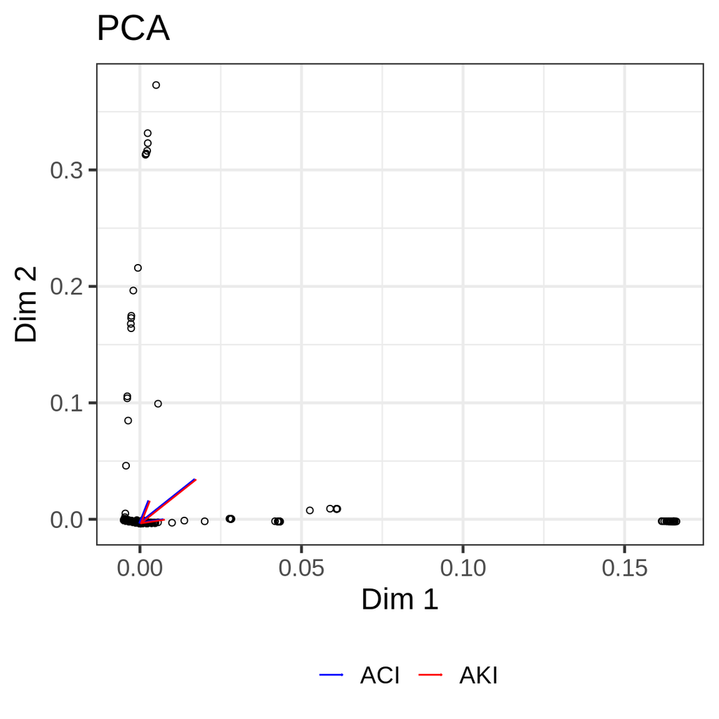

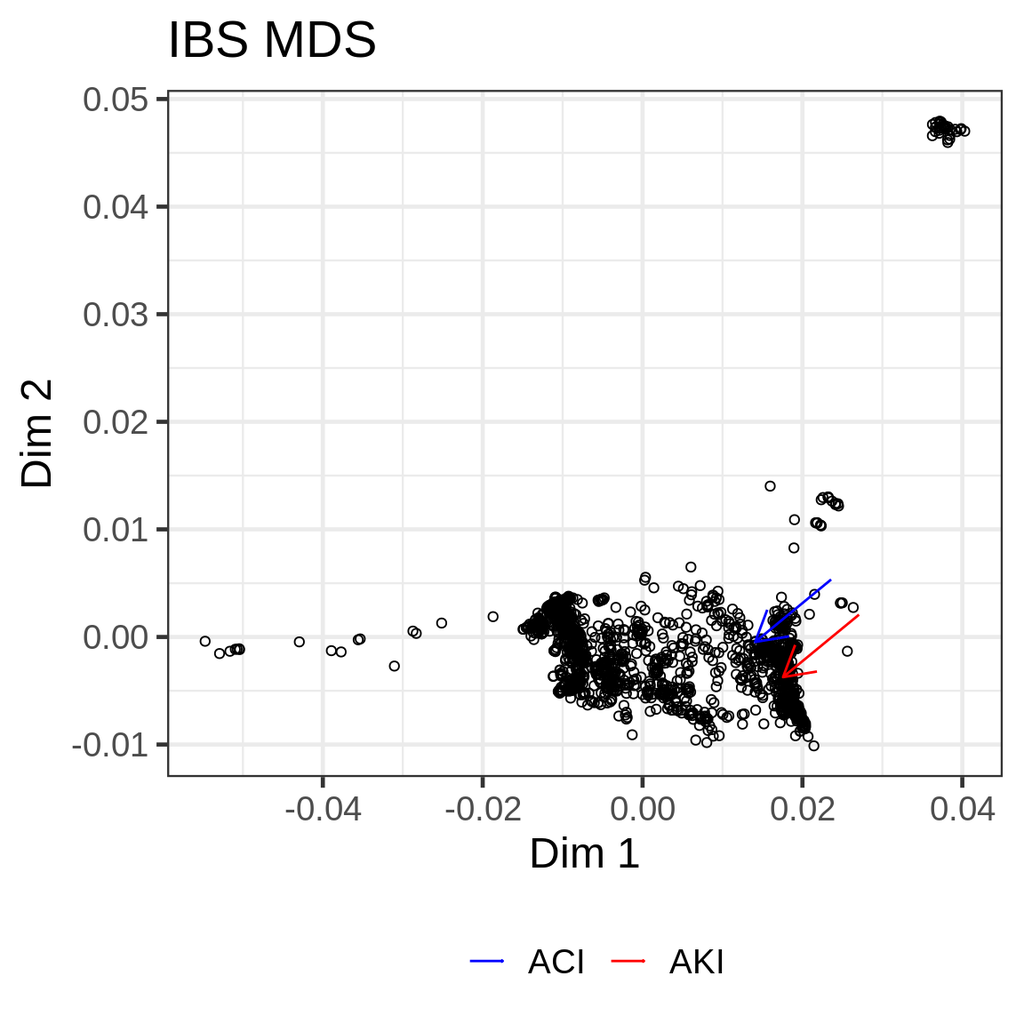

### 4.1.2 TRD region 3

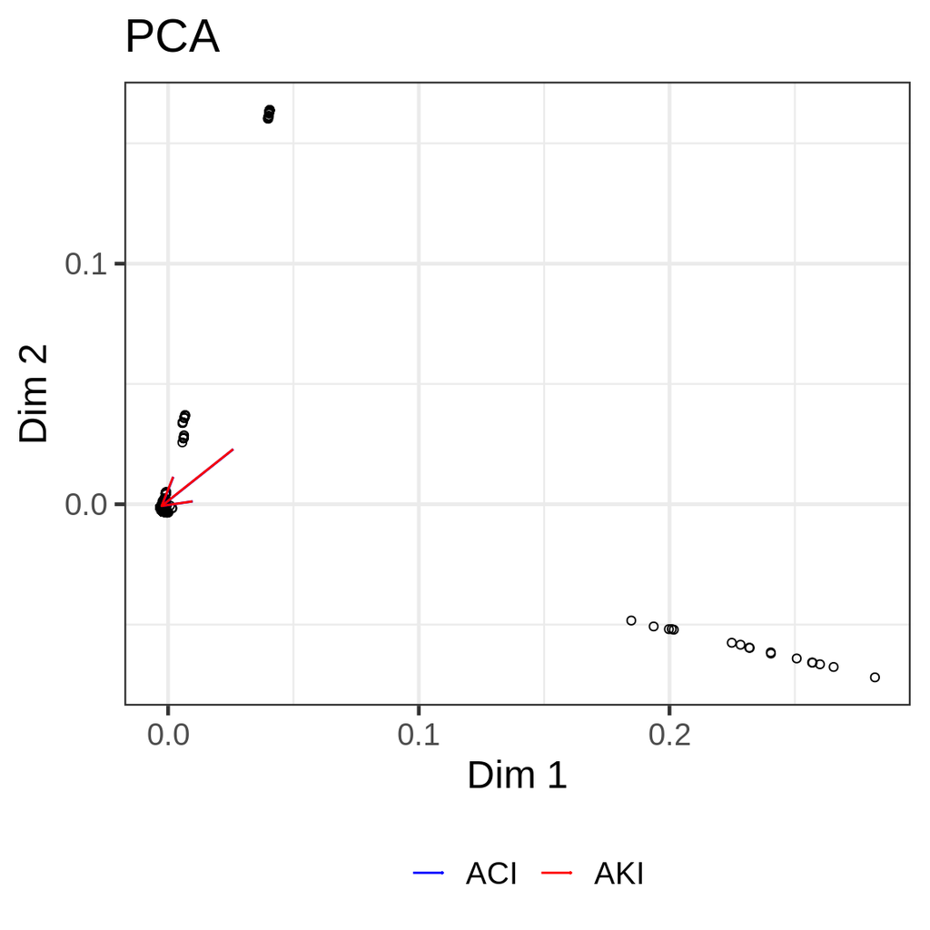

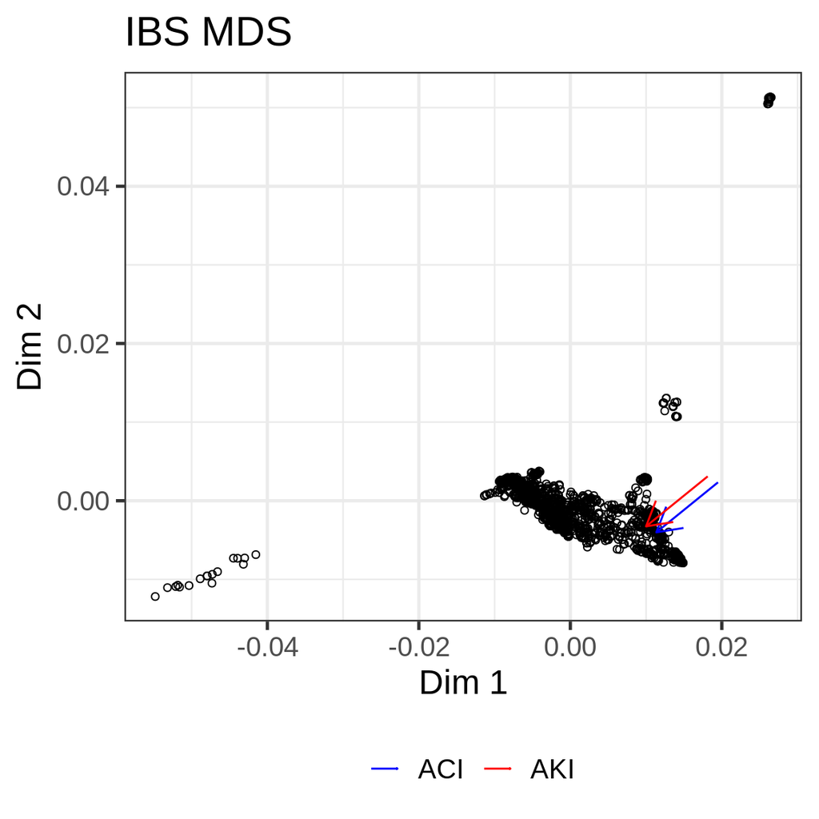

### 4.1.3 TRD region 4

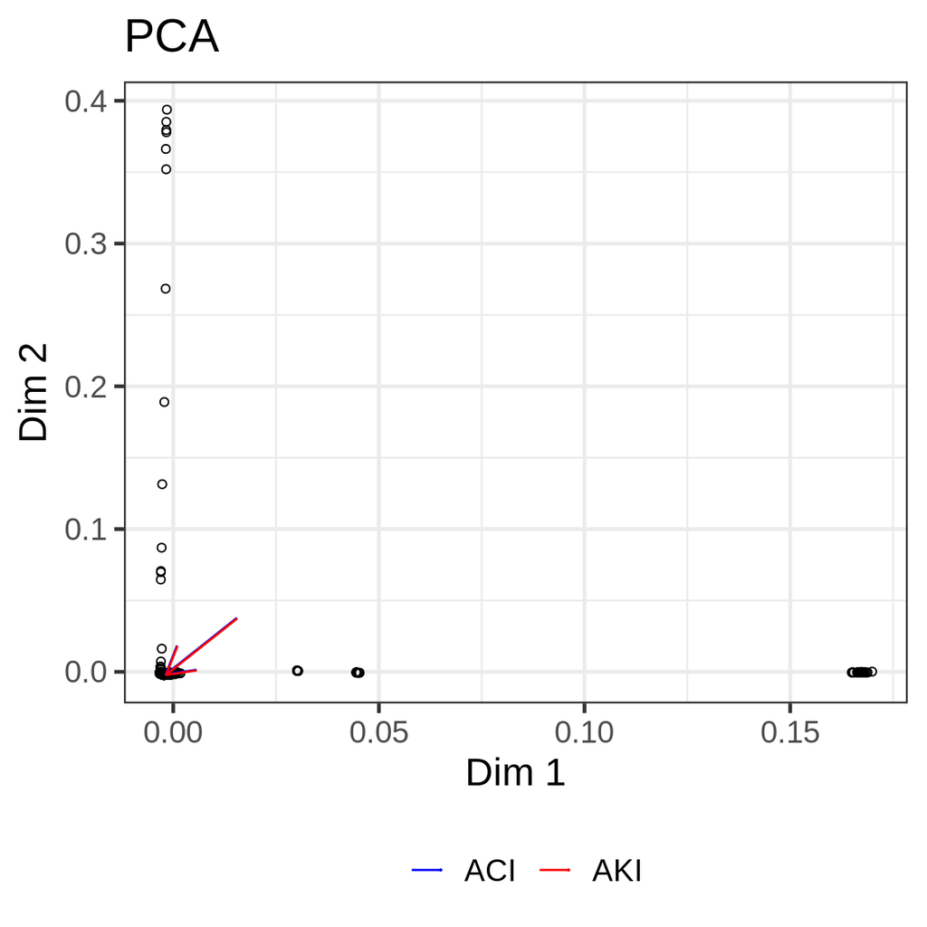

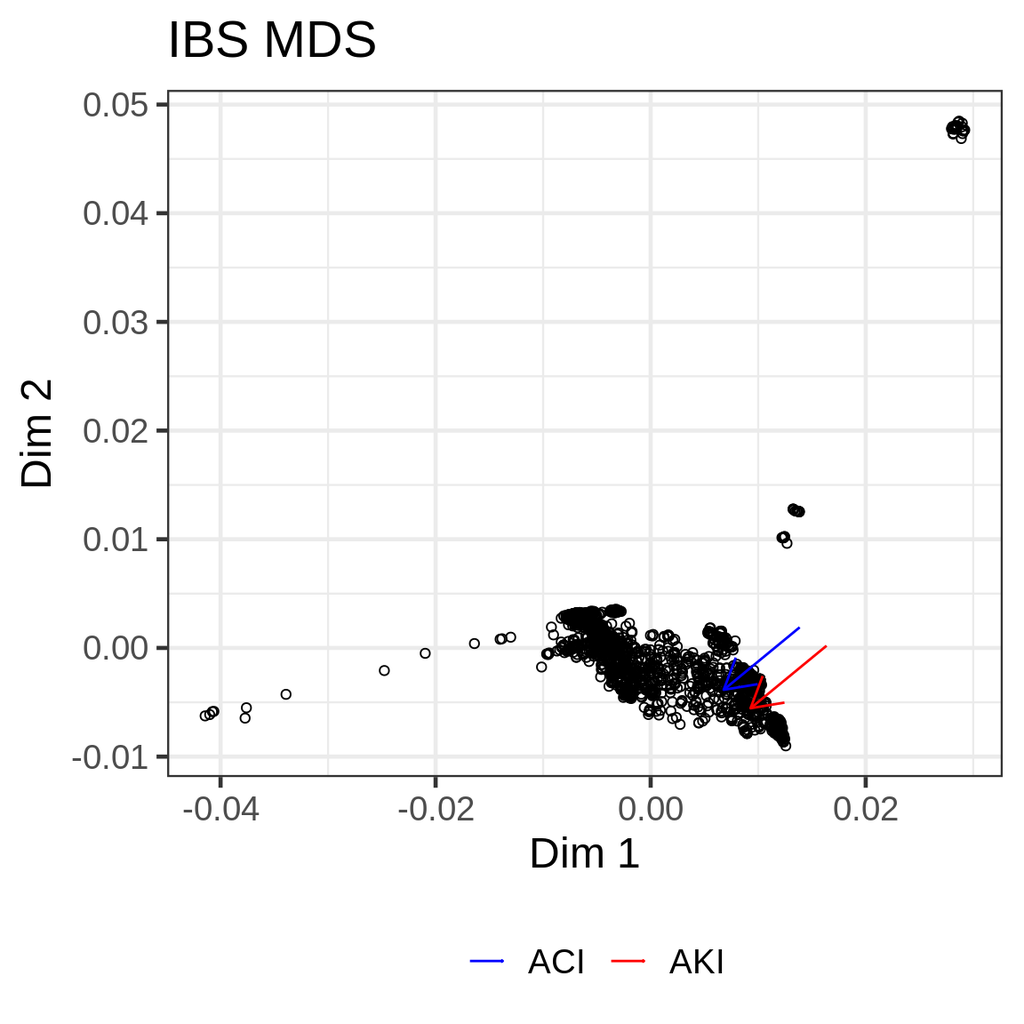

## 4.2 Distance plots

Next, we want to quantify how much the TRD regions are more or less distant to other strains in the PCA / IBS-MDS above compared to the rest of the strains’s genomes.

```r
for(id in pull(TRD_regions, ID)){

    cat("### TRD region ",id, " in strain 1, ", strain_1, "  ")
    cat("\n")
print(readRDS(paste0("~/data/trd/local_phylogenies_trd_analysis/",
                cross,".",id,".",strain_1,".","PCA",".RDS")))
              cat("\n")
print(readRDS(paste0("~/data/trd/local_phylogenies_trd_analysis/",
                cross,".",id,".",strain_1,".","IBS",".RDS")))
                cat("\n\n")

                cat("### TRD region ",id, " in strain 2, ", strain_2, "  ")
    cat("\n")
print(readRDS(paste0("~/data/trd/local_phylogenies_trd_analysis/",
                cross,".",id,".",strain_2,".","PCA",".RDS")))
              cat("\n")
print(readRDS(paste0("~/data/trd/local_phylogenies_trd_analysis/",
                cross,".",id,".",strain_2,".","IBS",".RDS")))
                cat("\n\n")
}
```

### 4.2.1 TRD region 1 in strain 1, ACI

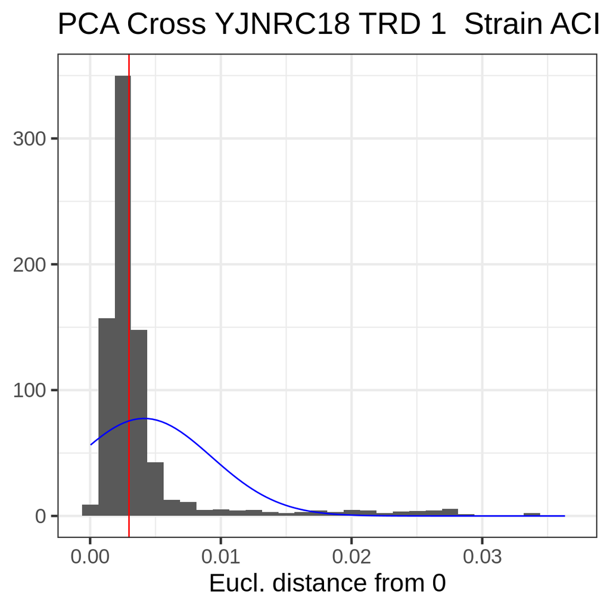

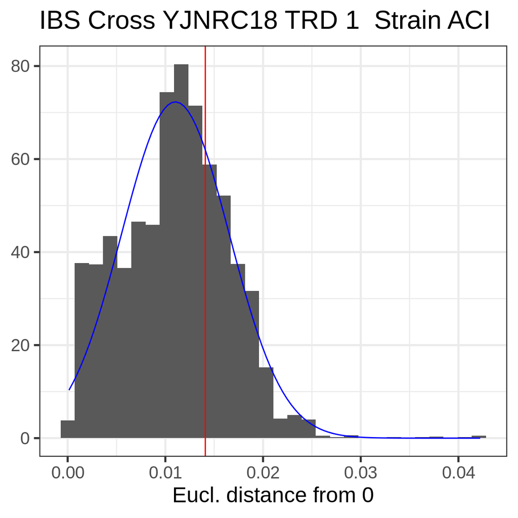

### 4.2.2 TRD region 1 in strain 2, AKI

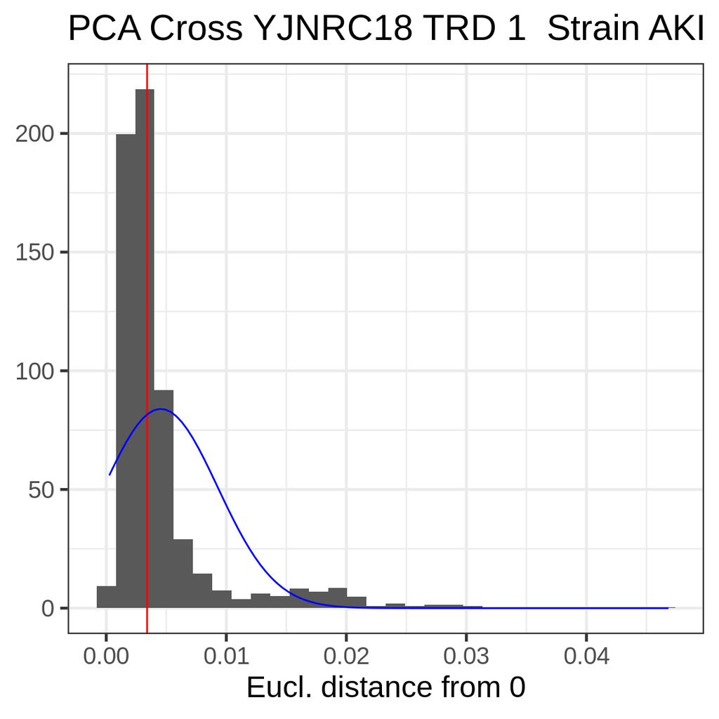

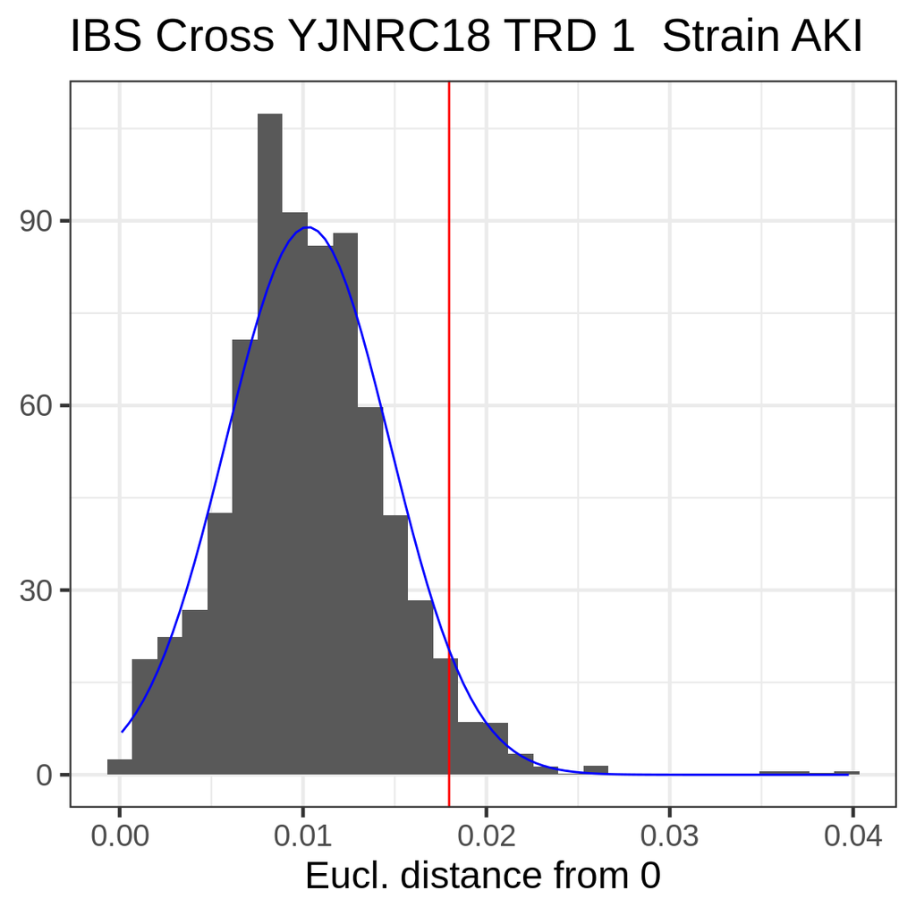

### 4.2.3 TRD region 3 in strain 1, ACI

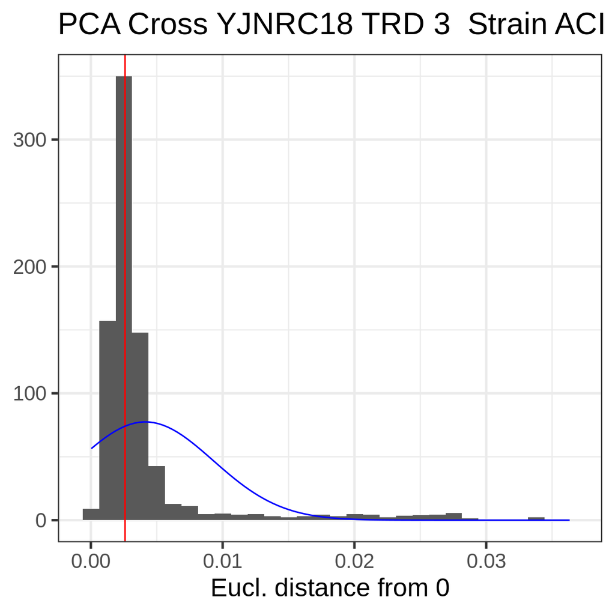

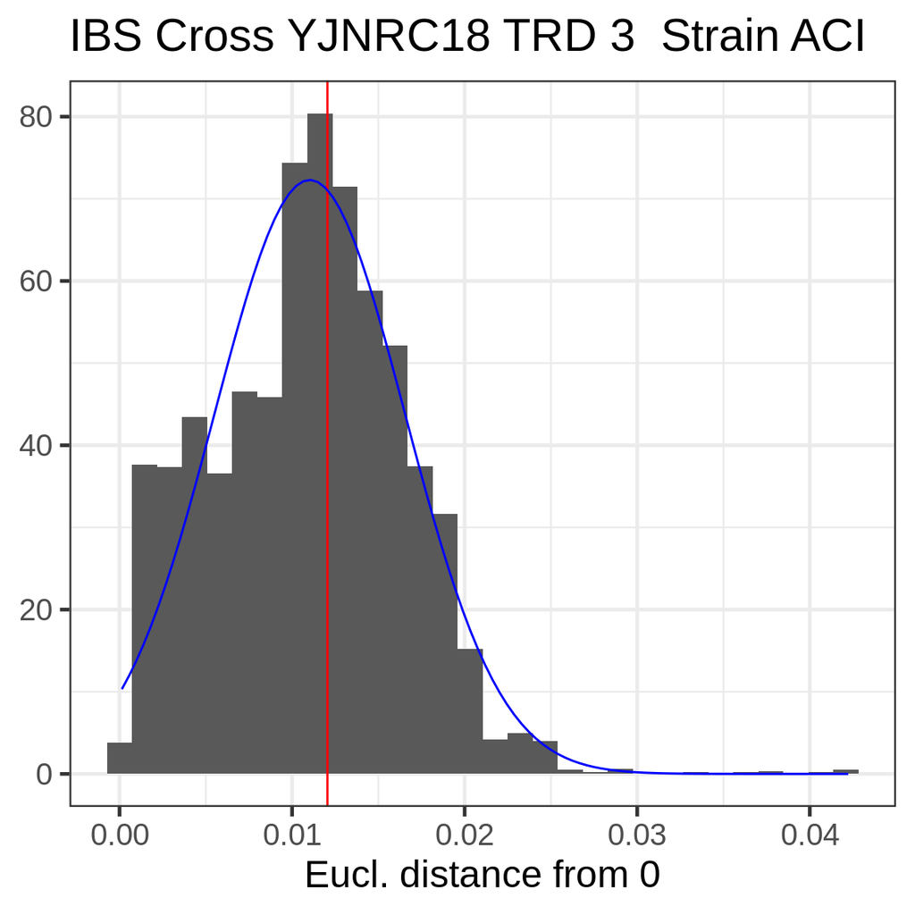

### 4.2.4 TRD region 3 in strain 2, AKI

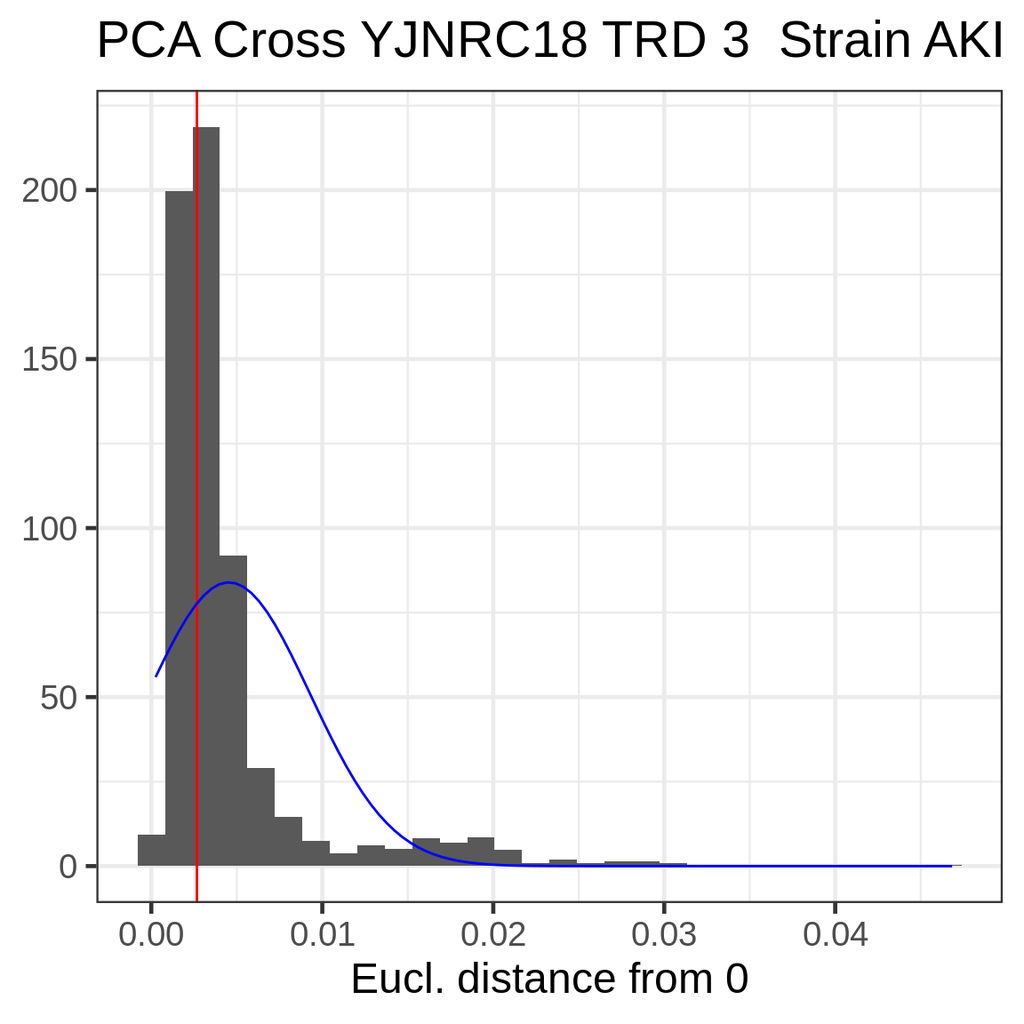

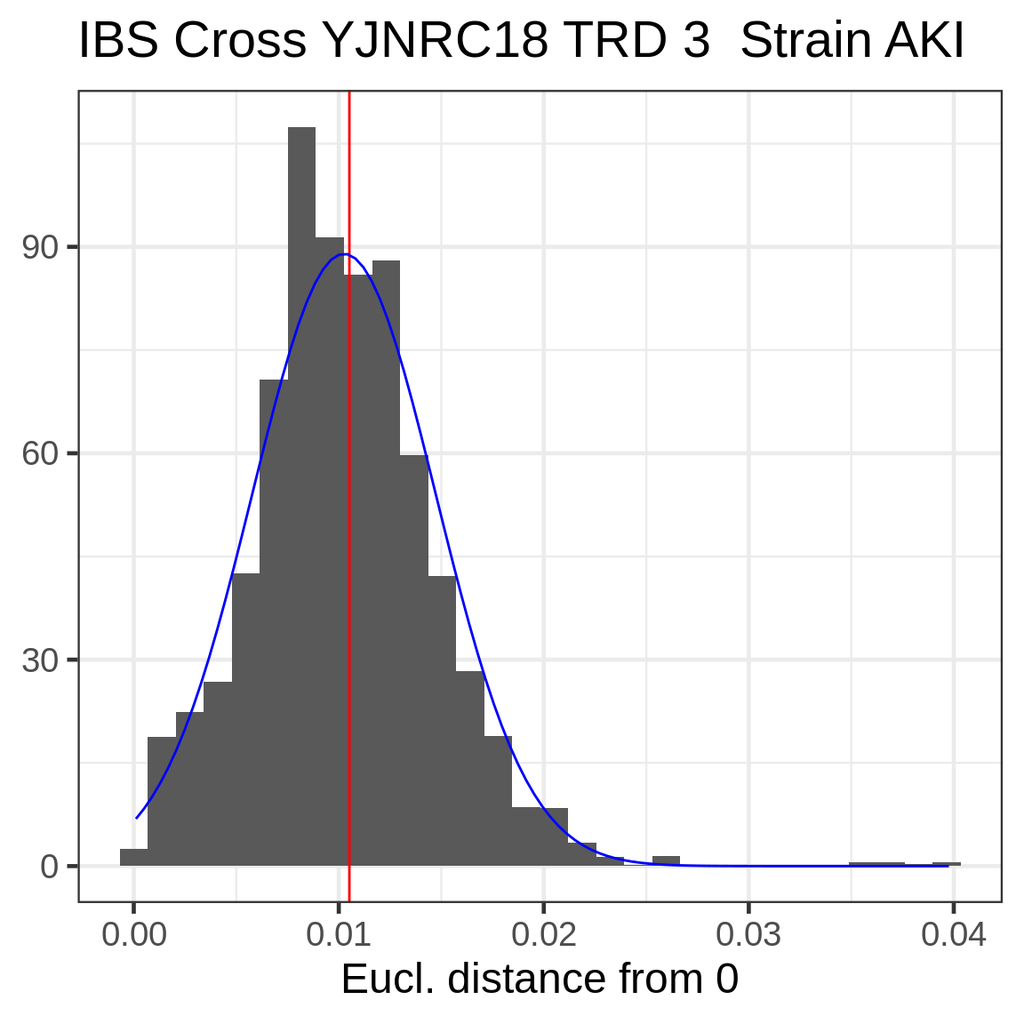

### 4.2.5 TRD region 4 in strain 1, ACI

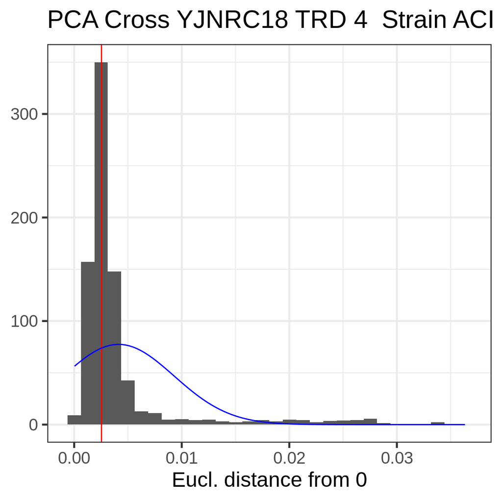

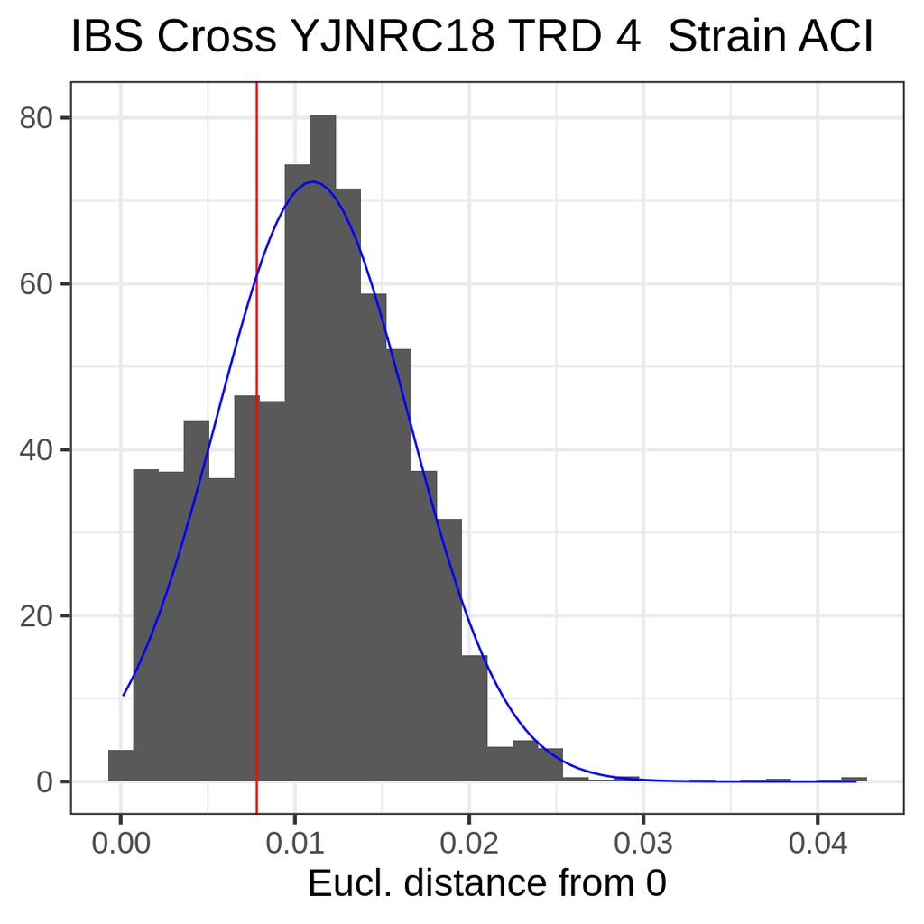

### 4.2.6 TRD region 4 in strain 2, AKI

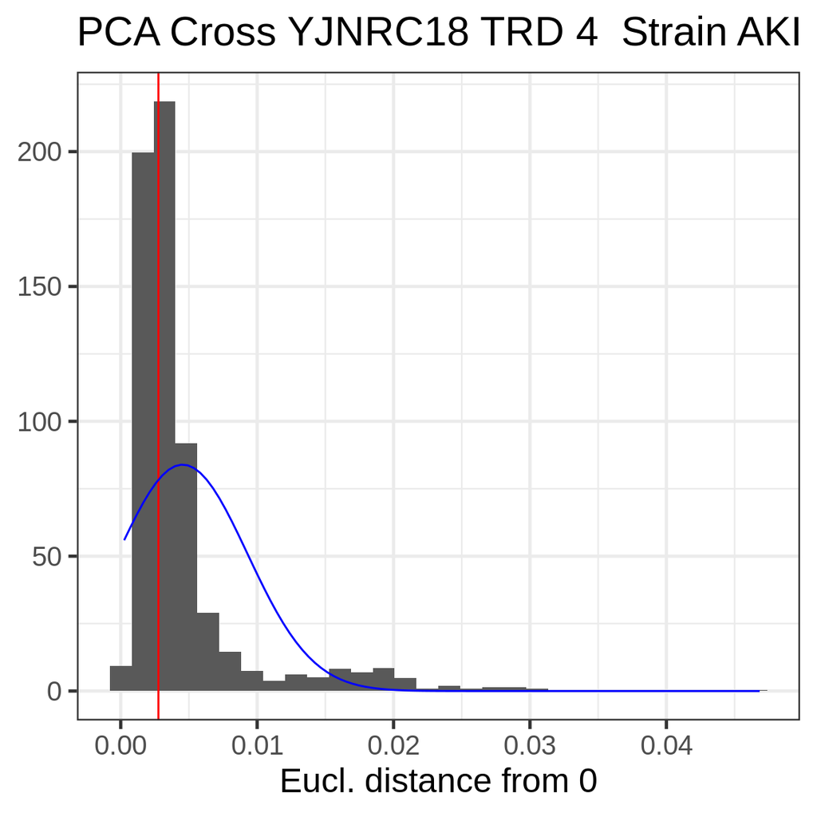

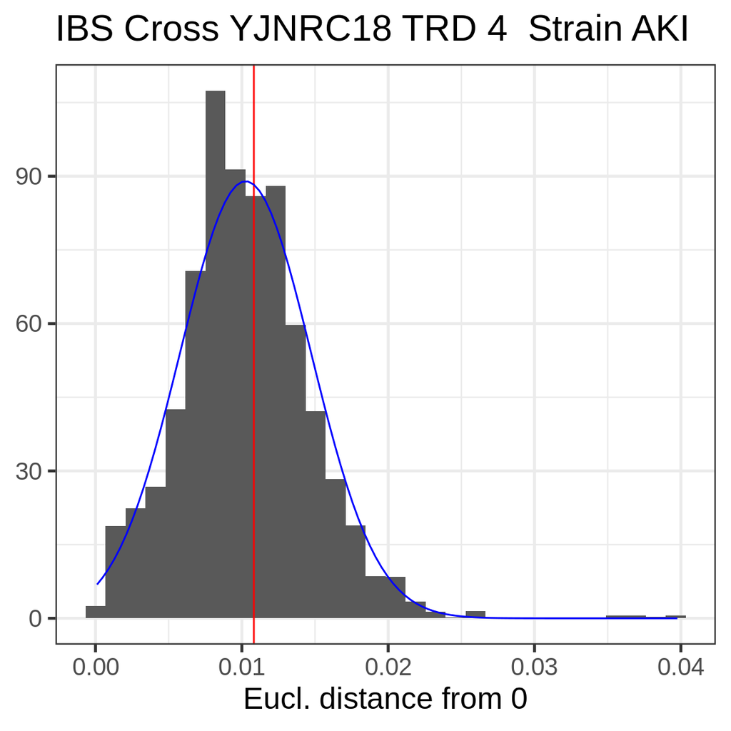

## 4.3 Changes in the local phylogeny

- needs to be re-analyzed as basically all TRD regions were low outliers, implying that the 50 kB region size of the random regions determined more changes than the often larger TRD regions.